# Analisis del Riesgo Segunda Entrega

# Introducción

# Análisis histórico del precio y de los rendimientos de Bolsa Mexicana de Valores.

# Causas de cambios

Gracias al la gran pandemia de COVID-19 y la gran incertidumbre que causó, además del continuo crecimiento de la inflación, por lo tanto, distintos inversionistas extranjeros decidieron retirar sus inversiones de tres mil 32 millones de dólares de la bolsa mexicana de valores, lo cual suponemos que fue una de las muchas causas que pudo provocar la caída del precio en este activo. Por otro lado, otro acontecimiento que pudo igualmente afectar,fue el acuerdo de OCDE (Organización para la Cooperación y el Desarrollo Económicos) que realizó Biden, para que las grandes tecnológicas paguen un 15% de impuesto de sociedades

# Rendimientos logaritmicos

Decidimos realizar el cálculo de los rendimientos logaritmicos, principalmente porque ha diferencia del rendimiento simple, este suma la rentabilidad de los distintos periodos para así dar la rentabilidad total.

[figure not shown]

Los rendimientos se obtuvieron de la siguiente forma:
$$R_t = ln P_{t+1} - ln P_t$$
Donde : $P_t = \text{Precio del activo en el tiempo t}$

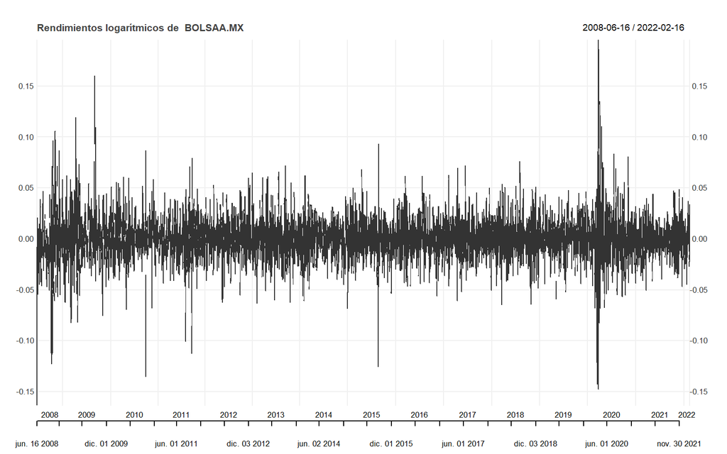

[figure not shown]